# Průběžný test č. 2

Michal Moudrý

5/5/2020

## Obsah

- První příklad
- Druhý příklad
- Třetí příklad

## První příklad

Obchodní společnost sledovala výkonnost svých pokladních ve 4 různých pobočkách (A, B, C, D). Na 10% hladině významnosti ověřte, zda se významně odlišuje průměrný počet obsloužených zákazníků za hodinu u jednotlivých pokladen v různých pobočkách. Pokud ano, určete koeﬁcient, který vyjadřuje míru této závislosti.

pobočka.A 51 36 34 57 54 67 66

pobočka.B 52 52 54 47 48 47 51

pobočka.C 42 59 21 72 74 88 66

pobočka.D 61 63 62 70 61 67 63

### Řešení

Pro ověření, zda se významně odlišuje průměrný počet obsloužených zákazníků za hodinu u jednotlivých pokladen v různých pobočkách je třeba spočítat testové kritérium (F) a podle toho, jestli spadá/nespadá do testového kritéria (Wα), tak buď zamítáme ve prospěch alternativy nebo ne.

- Alternativa je v tomto případě, že se průměrný počet obsloužených zákazníků za hodinu u jednotlivých pokladen významně odlišuje.

```r
pobocky_data <- data.frame(
  pobocky = c("A", "A", "A", "A", "A", "A", "A", "B", "B", "B", "B", "B", "B", "B", "C", "C", "C", "C", "C", "C", "C", "D", "D", "D", "D", "D", "D", "D"),
  obslouzeni_zakanici = c(51, 36, 34, 57, 54, 67, 66, 52, 52, 54, 47, 48, 47, 51, 42, 59, 21, 72, 74, 88, 66, 61, 63, 62, 70, 61, 67, 63)
)

qf(p = 0.9, df1 = 3, df2 = 24)
```

```
## [1] 2.32739
```

```r
pobocky_aov <- aov(formula = pobocky_data$obslouzeni_zakanici ~ pobocky_data$pobocky, data = pobocky_data)
pobocky_aov_summary <- summary(pobocky_aov)

meziskupinovy_rozptyl <- pobocky_aov_summary[[1]][["Sum Sq"]][[1]]
meziskupinovy_rozptyl
```

```
## [1] 894.6786
```

```r
vnitroskupinovy_rozptyl <- pobocky_aov_summary[[1]][["Sum Sq"]][[2]]
vnitroskupinovy_rozptyl
```

```
## [1] 4152
```

```r
pobocky_F <- (meziskupinovy_rozptyl/3)/(vnitroskupinovy_rozptyl/(length(pobocky_data$obslouzeni_zakanici) - 4))
pobocky_F
```

```
## [1] 1.723851
```

`Odpověď`:

- Testové kritérium … F = (meziskupinový rozptyl/[počet kategorií - 1])/(vnitroskupinový rozptyl/[počet prvků - počet kategorií])
  - F = (894,679/3)/(4152/24) = 1,723851
- α = 0,1
- F1-α = 2,32739
  - df1 = k - 1 = 4 - 1 = 3
  - df2 = n - k = 28 - 4 = 24
- Kritický obor: Wα = {F >= F1-α} = {1,723851 >= 2,32739}
- Nezamítáme ve prospěch alternativy, tedy průměrný počet obsloužených zákazníků za hodinu u jednotlivých pokladen v různých pobočkách se významně neodlišuje (tzn. není velký rozdíl mezi kategoriemi).

## Druhý příklad

U 19 pracovníků byla zjištěna výše jejich platu (Kč) a délka praxe (měsíce). Vstupní údaje jsou uspořádany v tabulce níže:

1. Pomocí regresní přímky vyjádřete závislost výše platu na délce praxe.
2. Pomocí testu ověřte, zda se jedná o vhodný model.
3. Pomocí vhodných testů ověřte významnost všech parametrů modelu.
4. Zhodnoťte kvalitu regresního modelu pomocí vhodného koeficientu a jeho hodnotu interpretujte.
5. Interpretujte věcně hodnotu vypočteného regresního koeficientu b_1.
6. Odhadněte střední hodnotu výše platu pro pracovníka s délkou praxe 72

### Definice proměnných

```r
pracovnici_data <- data.frame(
  plat = c(12475.40, 12086.24, 15081.52, 19619.64, 16994.36, 14589.36, 16493.48, 12544.12, 13949.08, 10610.84, 18142.40, 14774.16, 10154.92, 11348.00, 16246.84, 18058.12, 19503.32, 17058.60, 12990.72),
  delka_praxe = c(135, 56, 13, 91, 59, 84, 37, 53, 77, 71, 110, 4, 48, 75, 96, 78, 58, 40, 118)
)

fit_pracovnici <- lm (
  formula = pracovnici_data$plat ~ pracovnici_data$delka_praxe,
  data = pracovnici_data
)
summary_fit_pracovnici <- summary(fit_pracovnici)

b0 <- summary_fit_pracovnici$coefficients[1]
b1 <- summary_fit_pracovnici$coefficients[2]
```

### a) Závislost výše platu na délce praxe

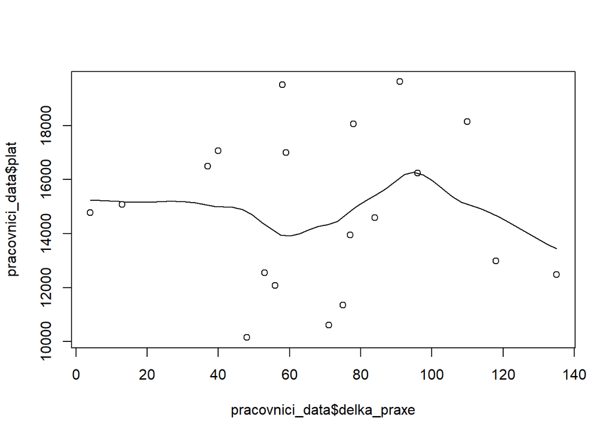

```r
scatter.smooth(pracovnici_data$delka_praxe, pracovnici_data$plat)
```

```r
b0
```

```
## [1] 14905.56
```

```r
b1
```

```
## [1] -0.3717925
```

y = 14905,56 + (-0.3717925) * x

### b) Test vhodnosti modelu

Pro otestování modelu (testují se všechny parametry najednou) je potřeba spočítat testové kritérium (F) a podle toho, jestli spadá/nespadá do testového kritéria (Wα), tak buď zamítáme ve prospěch alternativy nebo ne.

- Alternativa je v tomto případě, že mezi Y a X exsituje statisticky významná lineární závislost.

```r
summary_fit_pracovnici$fstatistic[1]
```

```
##       value
## 0.000309009
```

```r
qf(p = 0.95, df1 = 1, df2 = 17)
```

```
## [1] 4.451322
```

`Odpověď`:

- α = 0,05
- Stupně volnosti: df1 = p - 1, df2 = n - p
  - df1 = 2 - 1 = 1
  - df2 = 19 - 2 = 17
- F1-α = 4,451322
- Testové kritérium: F = 0,000309009
- Kritický obor: Wα = {F >= F1-α} = {0,000309009 >= 4,451322}
- p-hodnota: 0,9862
  - p-hodnota > α => nezamítáme hypotézu
- Nezamítáme ve prospěch alternativy, tedy mezi Y a X neexistuje statisticky významná lineární závislost.

### c) Významnost parametrů modelu

Pro otestování významnosti regresního parametru b1 je třeba spočítat t-hodnotu a podle toho, jestli spadá/nespadá do testového kritéria (Wα), tak buď zamítáme ve prospěch alternativy nebo ne.

- Alternativa je, jestli je lineární závislost s X *asi* statisticky významná.

H0: βj = 0

H1: βj != 0

```r
summary_fit_pracovnici$coefficients
```

```
##                                  Estimate Std. Error     t value     Pr(>|t|)
## (Intercept)                 14905.5560869 1607.30764  9.27361739 4.621509e-08
## pracovnici_data$delka_praxe    -0.3717925   21.15023 -0.01757865 9.861797e-01
```

`Odpověď`:

- α = 0,05
- t-hodnota: -0,01757865
- Stupně volnosti: 19 - 2 = 17
- t1-α/2 = t0.975 = 2,11
- Kritický obor: Wα = {|-0,01757865| >= 2,11}
- p-hodnota: 9,861797e-01
  - p-hodnota > α => nezamítáme hypotézu
- Nezamítáme testovanou hypotézu ve prospěch alternativy, tedy lineární závislost je statisticky nevýznamná.

### d) Kvalita regresního modelu

Kvalita regresního modelu se dá určit podle koeficientu determinace.

```r
summary_fit_pracovnici$r.squared
```

```
## [1] 1.817667e-05
```

`Odpověď`: V tomto případě hodnota koeficientu determinace je 1,817667e-05, tedy kvalita daného modelu je špatná, což znamená, že špatně vysvětluje variabilitu v souboru. Taky tento model špatně predikuje reálné datové body.

### e) Interpretujte věcně hodnotu vypočteného regresního koeficientu b_1.

```r
b1
```

```
## [1] -0.3717925
```

`Odpověď`: Koeficient B1 má hodnotu -0,3717925, tedy pokud se délka praxe pracovníka sníží/zvýší o 1, tak plat sníží/zvýší o -0,3717925 Kč.

### f) Odhadněte střední hodnotu výše platu pro pracovníka s délkou praxe 72

Pro odhad střední hodnoty stačí dosadit do vzorce pro regresní přímku, tedy y = b0 + b1 * x, kdy x je v tomto případě 72.

y = 14905,56 + (-0,3717925) * 72

```r
b0 + (b1 * 72)
```

```
## [1] 14878.79
```

`Odpověď`: Odhadnutá střední hodnota výše platu je 14878,79 Kč.

## Třetí příklad

Jedna velká potravinářská firma, získala oznámení od dotační komise, že ji v rámci dotačního programu na podporu malých podnikatelů byla udělena dotace. Výše dotace ještě nebyla stanovena. Firma předpokládá, že výše dotace bude asi 60819429 Kč. Firma si udělala průzkum u 7 svých konkurentů. Nezávislý odborník předpokládá, že výše dotace bude nižší než předpoklad firmy. Ověřte na hladině významnosti 0.1 %, zda má pravdu spíš firma nebo nezávislý odborník (předpokládejte, že výše dotace má normální rozdělení).

### Řešení

Pro otestování hypotézy, zda má pravdu nezávislý odborník předpokládá, že výše dotace bude nižší než předpoklad firmy je třeba spočítat střední hodnotu normálního rozdělení, testové kritérium (T).

Předpoklad H0: μ = μ0 = 60 819 429

Alternativa H1: μ < μ0

```r
dotace_konkurenci <- c(53800000, 69100000, 47100000, 51600000, 64000000, 61700000, 46900000)
prumer_dotaci <- mean(dotace_konkurenci)
dotace_sd <- sqrt((sum((dotace_konkurenci - prumer_dotaci) ^ 2))/(length(dotace_konkurenci) - 1))
dotace_T <- ((prumer_dotaci - 60819429) / dotace_sd) * sqrt(length(dotace_konkurenci))
dotace_T
```

```
## [1] -1.370828
```

```r
qt(p = 0.99, df = 6)
```

```
## [1] 3.142668
```